# Module 7 HW - Question 1

Implement k-means from scratch. You are given a dataset X whose rows represent different data points, you are asked to perform a k-means clustering on this dataset using the Manhattan Distance, k is chosen as 3.

$$X = \begin{bmatrix} 5.7 & 64 \\ 4.7 & 58 \\ 6.1 & 56 \\ 4.6 & 64 \\ 5.4 & 84 \\ 4.9 & 60 \\ 5.0 & 62 \\ 6.4 & 62 \\ 5.1 & 76 \\ 6.0 & 60 \\ \end{bmatrix}$$

The Manhattan Distance of $(x_1,y_1)$ and $(x_2,y_2)$ is calculated by

$\text{Dist} = |x_1-x_2|+|y_1- y_2 |$

# Module 7 HW - Question 1.a

Since first column and second column are not on the same scale. Before running K-means, this dataset needs to be preprocessed, Show the preprocessed dataset. (Answer in the format of [x1, x2], round your results to two decimal places, same as problems b and c)

We will conduct normalization on the dataset in order to be sure that the values are on the same scale. We will use Min-Max Scaling($x_{\text{normalized}} = \frac{x - min(x)}{max(x) - min(x)}$) to conduct the normalization on the data. This normalization will scale the first feature data and second feature data to values between 0 and 1.

```python
# import required packages
import numpy as np
import copy

# set the data into an array
X = np.array([
    [5.7, 64],
    [4.7, 58],
    [6.1, 56],
    [4.6, 64],
    [5.4, 84],
    [4.9, 60],
    [5.0, 62],
    [6.4, 62],
    [5.1, 76],
    [6.0, 60]
])

# define a function for min max scaling
def min_max_scale(X):

    X_pp = copy.deepcopy(X)
    for col in range(X.shape[1]):
        for row in range(len(X)):
            X_pp[row, col] = (X[row, col] - X[:, col].min())/(X[:, col].max() - X[:, col].min())

    return X_pp
```

```
[[0.61111111 0.28571429]
 [0.05555556 0.07142857]
 [0.83333333 0.        ]
 [0.         0.28571429]
 [0.44444444 1.        ]
 [0.16666667 0.14285714]
 [0.22222222 0.21428571]
 [1.         0.21428571]
 [0.27777778 0.71428571]
 [0.77777778 0.14285714]]
```

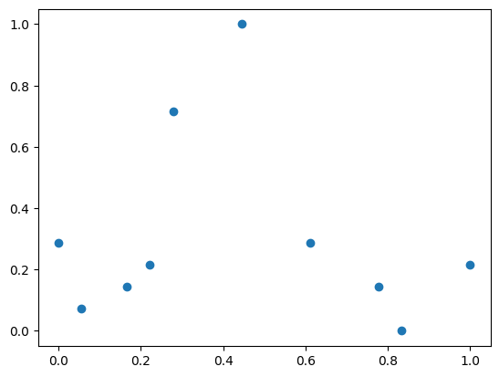

```python
# import plotting packages
import matplotlib.pyplot as plt

# apply min max scaling to our data
X_pp = min_max_scale(X)
print(X_pp)

# plot the normalized data
plt.scatter(X_pp[:, 0], X_pp[:, 1])
plt.show()
```

# Module 7 HW - Question 1.b

Suppose the initial centroids of the clusters are $\mu_1=[5.6,60]$, $\mu_2=[5.9,60]$, $\mu_3=[5.2,75]$ . What’s the center of the second cluster after two iterations?

These centroids need to be normalized first. Once they are normalized then we can calculate the first iteration of manhattan distances between each value and the centroids to determine which values lie closest to each centroid. Once we identify those values we can then calculate the mean distances in order to find the second clusters/centroids.

```
c1 preprocessed:  [[0.55555556 0.14285714]]
c2 preprocessed:  [[0.72222222 0.14285714]]
c3 preprocessed:  [[0.33333333 0.67857143]]
```

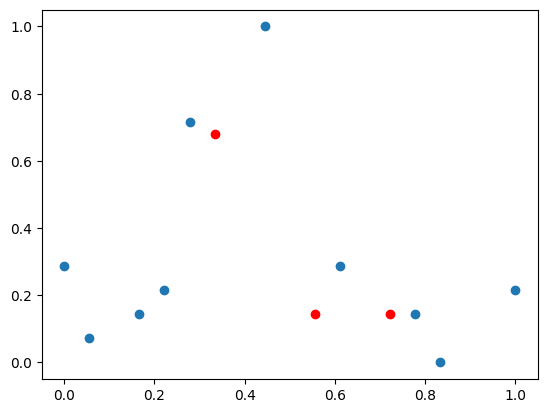

```python
# set un-normalized centroids in arrays
c1 = np.array([[5.6, 60]])
c2 = np.array([[5.9, 60]])
c3 = np.array([[5.2, 75]])

# set min and max values for each column of the dataset.
X_0_min = X[:, 0].min()
X_0_max = X[:, 0].max()
X_1_min = X[:, 1].min()
X_1_max = X[:, 1].max()

# standardize data based on original data
c1_pp = np.array([
    [(c1[0, 0]-X_0_min)/(X_0_max-X_0_min), (c1[0, 1]-X_1_min)/(X_1_max-X_1_min)]
])

c2_pp = np.array([
    [(c2[0, 0]-X_0_min)/(X_0_max-X_0_min), (c2[0, 1]-X_1_min)/(X_1_max-X_1_min)]
])

c3_pp = np.array([
    [(c3[0, 0]-X_0_min)/(X_0_max-X_0_min), (c3[0, 1]-X_1_min)/(X_1_max-X_1_min)]
])

# print the results
print('c1 preprocessed: ', c1_pp)
print('c2 preprocessed: ', c2_pp)
print('c3 preprocessed: ', c3_pp)

# plot the normalized centroids
plt.scatter(X_pp[:, 0], X_pp[:, 1])
plt.scatter(np.array([c1_pp[0], c2_pp[0], c3_pp[0]])[:, 0], np.array([c1_pp[0], c2_pp[0], c3_pp[0]])[:, 1], color='red')
plt.show()
```

Now we can calculate the manhatten distance of the centroids between each point and determine which points are closests to each centroid.

```
normalized array with centroid category set using Manhatten Distances
[[0.61111111 0.28571429 1.        ]
 [0.05555556 0.07142857 1.        ]
 [0.83333333 0.         2.        ]
 [0.         0.28571429 1.        ]
 [0.44444444 1.         3.        ]
 [0.16666667 0.14285714 1.        ]
 [0.22222222 0.21428571 1.        ]
 [1.         0.21428571 2.        ]
 [0.27777778 0.71428571 3.        ]
 [0.77777778 0.14285714 2.        ]]


Initial Centroids
{1: array([[0.55555556, 0.14285714]]), 2: array([[0.72222222, 0.14285714]]), 3: array([[0.33333333, 0.67857143]])}


1 Iteration: New Centroids
{1: array([[0.21111111, 0.2       ]]), 2: array([[0.87037037, 0.11904762]]), 3: array([[0.36111111, 0.85714286]])}


1 Iteration: Centroid Distance Values
{1: 0.40476190476190443, 2: 0.05555555555555536, 3: 0.0912698412698415}
```

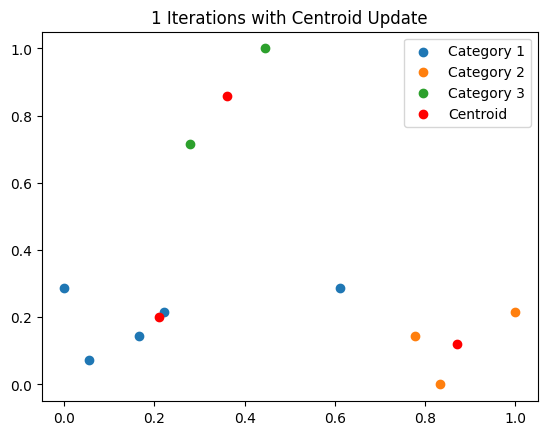

```python
# creating a centroids dictionary to iterate through preprocessed centroid data
cent_dict = {1: c1_pp, 2: c2_pp, 3: c3_pp}

# manhatten distance calculations and new centroid locations
def manhattan_dist_calc(X, centroids_dict):

    # copy array to return newly created array with centroid and remove cluster label if it is available in the dataset
    X_md = copy.deepcopy(X)
    X_md = X_md[:, 0:2]
    X_md = np.hstack((X_md, np.zeros((X_md.shape[0], 1))))

    # dictionary to hold centroid distance values to answer question 1.b
    centroid_distance_values = {}

    # check the distance of each point in the array from each centroid and appoint the smallest value
    for row in range(len(X)):
        # used to hold manhatten distance values for each centroid
        temp_cent_dict_ = {}
        for dict_name in centroids_dict:
            # calculate the manhatten distance for the centroid
            temp_cent_dict_.update({dict_name: abs(X[row, 0] - centroids_dict[dict_name][0][0]) + np.abs(X[row, 1] - centroids_dict[dict_name][0][1])})

        # get minimum valued centroid to set as label for that cluster
        min_centroid = min(zip(temp_cent_dict_.values(), temp_cent_dict_.keys()))[1]
        centroid_distance_values.update({min(zip(temp_cent_dict_.values(), temp_cent_dict_.keys()))[1]: min(zip(temp_cent_dict_.values(), temp_cent_dict_.keys()))[0]})
        X_md[row, 2] = min_centroid

    # calculate new centroids
    # list of unique centroid categories
    centroid_cat = np.unique(X_md[:, 2])

    # empty array that will hold our new centroids
    centroid_array = np.zeros((len(np.unique(X_md[:, 2])), 2))

    # updating the centroids dictionary so we can re-run this function to find convergence
    centroids_dict_copy = copy.deepcopy(centroids_dict)

    # loop to iterate through data and calculate centroid means
    for num, cent_cat in enumerate(centroid_cat):
        X_cent_mean = X_md[X_md[:, 2] == cent_cat][:, 0].mean()
        y_cent_mean = X_md[X_md[:, 2] == cent_cat][:, 1].mean()

        # setting centroid means into a centroid array that will be used for visualizations
        centroid_array[num, 0] = X_cent_mean
        centroid_array[num, 1] = y_cent_mean

        # setting centroid means into a new dictioanry that we will use for iterations
        centroids_dict_copy[cent_cat] = np.array([[X_cent_mean, y_cent_mean]])


    return X_md, centroid_array, centroids_dict_copy, centroid_distance_values

X_labeled, cent_array1, new_cent_dict1, centroid_distance_values1 = manhattan_dist_calc(X_pp, cent_dict)

print('normalized array with centroid category set using Manhatten Distances')
print(X_labeled)

print('\n\nInitial Centroids')
print(cent_dict, '\n\n')

print('1 Iteration: New Centroids')
print(new_cent_dict1, '\n\n')

print('1 Iteration: Centroid Distance Values')
print(centroid_distance_values1, '\n\n')

# extracting x, y, and category values
x = X_labeled[:, 0]
y = X_labeled[:, 1]
categories = X_labeled[:, 2]

# get unique categories
unique_categories = np.unique(categories)

# plot each category
for category in unique_categories:
    # select data for the category
    idx = categories == category
    plt.scatter(x[idx], y[idx], label=f'Category {int(category)}')
plt.scatter(cent_array1[:, 0], cent_array1[:, 1], color='red', label='Centroid')
plt.legend()
plt.title('1 Iterations with Centroid Update')
plt.show()
```

```
Initial Centroids
{1: array([[0.55555556, 0.14285714]]), 2: array([[0.72222222, 0.14285714]]), 3: array([[0.33333333, 0.67857143]])}


1 Iteration: New Centroids
{1: array([[0.21111111, 0.2       ]]), 2: array([[0.87037037, 0.11904762]]), 3: array([[0.36111111, 0.85714286]])}


1 Iteration: Centroid Distance Values
{1: 0.40476190476190443, 2: 0.05555555555555536, 3: 0.0912698412698415}


2 Iteration: New Centroids
{1: array([[0.11111111, 0.17857143]]), 2: array([[0.80555556, 0.16071429]]), 3: array([[0.36111111, 0.85714286]])}


2 Iteration: Centroid Distance Values
{2: 0.11640211640211638, 1: 0.025396825396825362, 3: 0.22619047619047639}
```

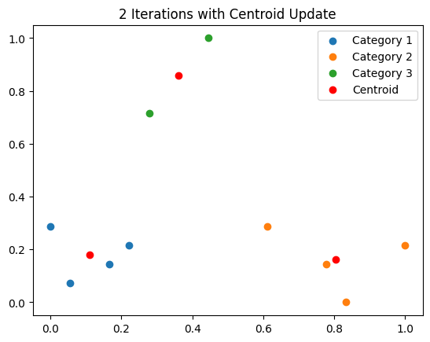

```python
print('Initial Centroids')
print(cent_dict, '\n\n')

print('1 Iteration: New Centroids')
print(new_cent_dict1, '\n\n')

print('1 Iteration: Centroid Distance Values')
print(centroid_distance_values1, '\n\n')

X_labeled2, cent_array2, new_cent_dict2, centroid_distance_values2 = manhattan_dist_calc(X_pp, new_cent_dict1)

print('2 Iteration: New Centroids')
print(new_cent_dict2, '\n\n')

print('2 Iteration: Centroid Distance Values')
print(centroid_distance_values2, '\n\n')

# extracting x, y, and category values
x = X_labeled2[:, 0]
y = X_labeled2[:, 1]
categories = X_labeled2[:, 2]

# get unique categories
unique_categories = np.unique(categories)

# plot each category
for category in unique_categories:
    # select data for the category
    idx = categories == category
    plt.scatter(x[idx], y[idx], label=f'Category {int(category)}')
plt.scatter(cent_array2[:, 0], cent_array2[:, 1], color='red', label='Centroid')
plt.legend()
plt.title('2 Iterations with Centroid Update')
plt.show()
```